# Session 4: Descriptive and exploratory network analysis

Describing the whole network, positions within it, and groups

Published

October 4, 2026

## Goals

- describe a network at three levels: **whole network**, **nodes**, **groups**,
- understand what each centrality measure actually counts,
- detect communities and test for homophily,
- visualise networks so the picture supports, rather than replaces, the analysis.

```r
library(tidyverse)
library(igraph)
library(tidygraph)
library(ggraph)
```

We practise on a small, well-known network before moving to IR data.

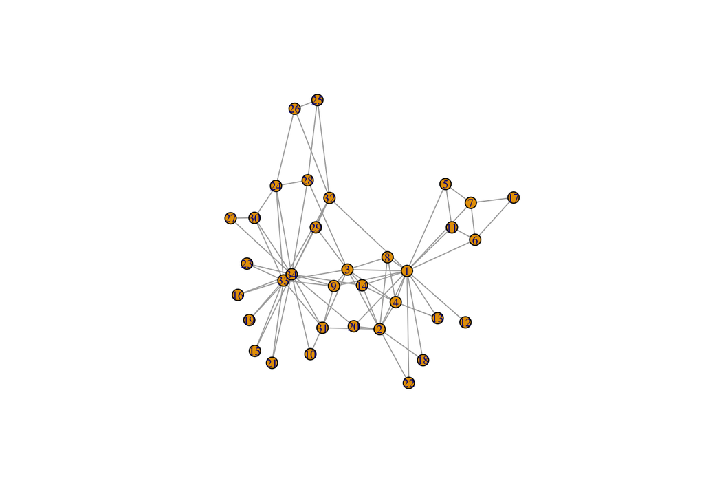

```r
g <- make_graph("Zachary")
plot(g, vertex.size = 8, vertex.label.cex = 0.7)
```

## 1. Whole-network level

**NoteThink first**

For each measure below, write down in one sentence what it counts *before* you run the code.

```r
tibble(
  nodes        = vcount(g),
  edges        = ecount(g),
  density      = edge_density(g),
  components   = components(g)$no,
  transitivity = transitivity(g, type = "global"),
  avg_path     = mean_distance(g),
  diameter     = diameter(g)
)
```

```
# A tibble: 1 × 7
  nodes edges density components transitivity avg_path diameter
  <dbl> <dbl>   <dbl>      <dbl>        <dbl>    <dbl>    <dbl>
1    34    78   0.139          1        0.256     2.41        5
```

Degree distribution: are ties spread evenly or concentrated on a few nodes?

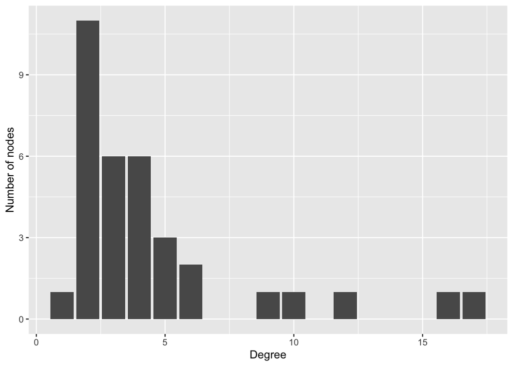

```r
tibble(degree = degree(g)) |>
  ggplot(aes(degree)) +
  geom_bar() +
  labs(x = "Degree", y = "Number of nodes")
```

## 2. Node level: centrality

Different centrality measures formalise different ideas of importance:

| Measure | Idea | IR intuition |
| --- | --- | --- |
| Degree | how many ties | number of trade partners |
| Betweenness | how often on shortest paths between others | broker, gatekeeper |
| Closeness | how close to everyone else | reach, speed of diffusion |
| Eigenvector | tied to well-connected others | ties to great powers |

```r
centralities <- tibble(
  node        = 1:vcount(g),
  degree      = degree(g),
  betweenness = betweenness(g),
  closeness   = closeness(g),
  eigenvector = eigen_centrality(g)$vector
)

centralities |> arrange(desc(betweenness)) |> head()
```

```
# A tibble: 6 × 5
   node degree betweenness closeness eigenvector
  <int>  <dbl>       <dbl>     <dbl>       <dbl>
1     1     16       231.     0.0172       0.952
2    34     17       161.     0.0167       1
3    33     12        76.7    0.0156       0.827
4     3     10        75.9    0.0169       0.850
5    32      6        73.0    0.0164       0.512
6     9      5        29.5    0.0156       0.609
```

**NoteThink first**

Are the measures strongly correlated? Find a node that ranks high on one and low on another, and explain why using the network plot.

```r
cor(centralities[, -1], method = "spearman") |> round(2)
```

```
            degree betweenness closeness eigenvector
degree        1.00        0.90      0.89        0.78
betweenness   0.90        1.00      0.90        0.69
closeness     0.89        0.90      1.00        0.86
eigenvector   0.78        0.69      0.86        1.00
```

## 3. Group level: communities and homophily

```r
comm <- cluster_louvain(g)
sizes(comm)
```

```
Community sizes
 1  2  3  4
12  5 11  6
```

```r
modularity(comm)
```

```
[1] 0.4188034
```

**Homophily** (assortativity): do similar nodes tie to each other? Here we use degree: do well-connected nodes connect to other well-connected nodes?

```r
assortativity_degree(g)
```

```
[1] -0.4756131
```

With a node attribute such as regime type, `assortativity_nominal()` asks whether democracies tie to democracies.

## 4. Visualisation with ggraph

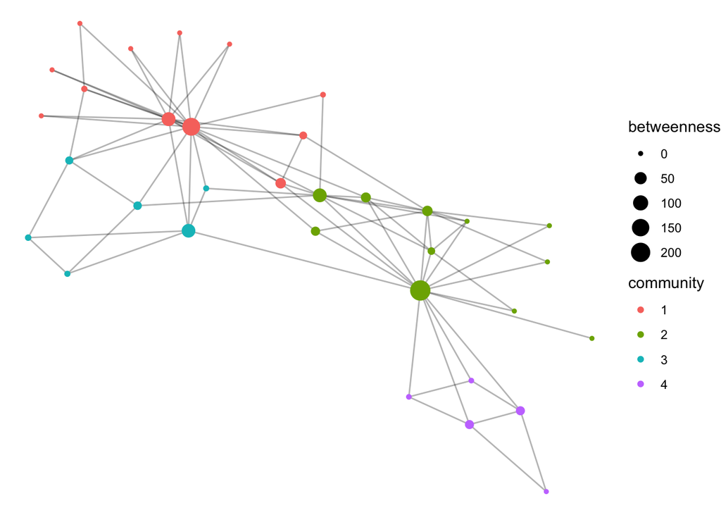

```r
g |>
  as_tbl_graph() |>
  activate(nodes) |>
  mutate(
    betweenness = centrality_betweenness(),
    community   = as.factor(group_louvain())
  ) |>
  ggraph(layout = "fr") +
  geom_edge_link(alpha = 0.3) +
  geom_node_point(aes(size = betweenness, colour = community)) +
  theme_void()
```

**WarningDiscuss**

Re-run the plot several times. The layout changes, the network does not. What can and cannot be read from a network plot?

## Your turn

**TipExercise**

1. Apply the whole-network table to the cleaned data from Session 3. Compare density with and without isolates.
2. Identify the three most central nodes by degree and by betweenness. Interpret any difference substantively.
3. Plot the network with node size = degree and colour = a node attribute of your choice.

```r
# your code here
```